# Analyse bioinformatique des données moléculaires à haut débit en Oncologie

## Diagramme thermique (Sans normalisation **d’affichage**)

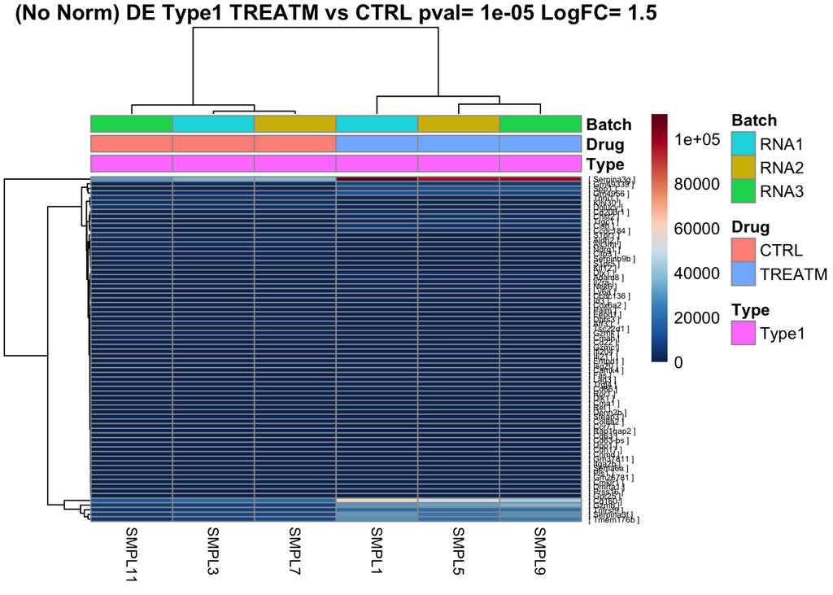

## Analyse **EdgeR** avec statistiques

Un **test statistique** sur les **profils d’expression** permet de détecter les gènes **différentiellement** exprimés.

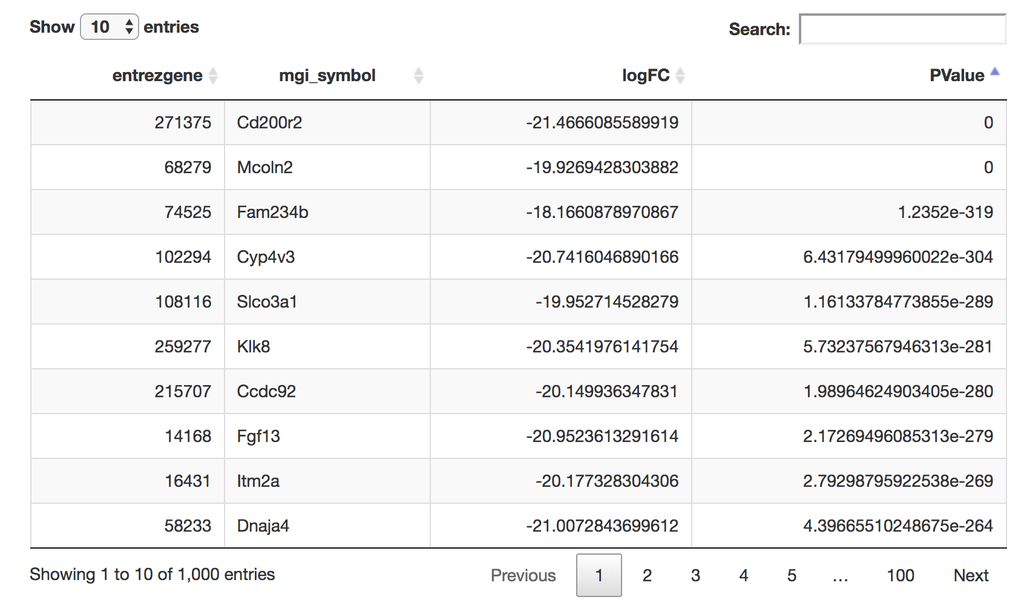

## Diagramme en volcan

- \(|LogFC|>1.5, pval<10^{-3}\)

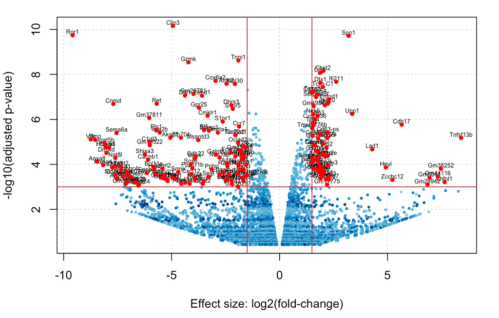

## Diagramme en volcan

- \(|LogFC|>2.0, pval<10^{-5}\)

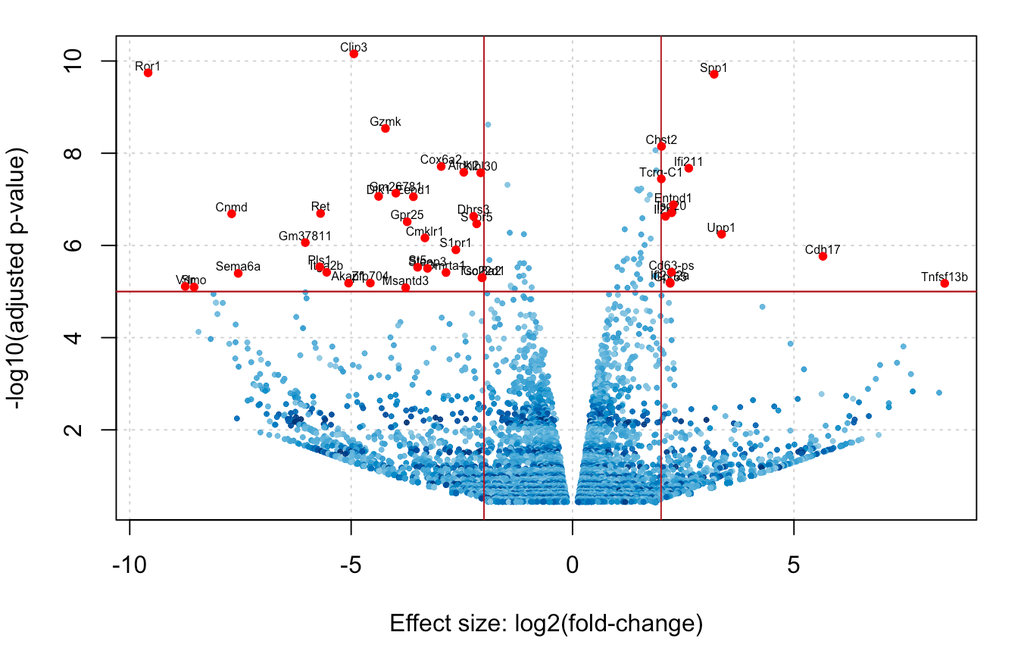

## Analyse fonctionnelle des gènes

## Analyse fonctionnelle par enrichissement: principe (1)

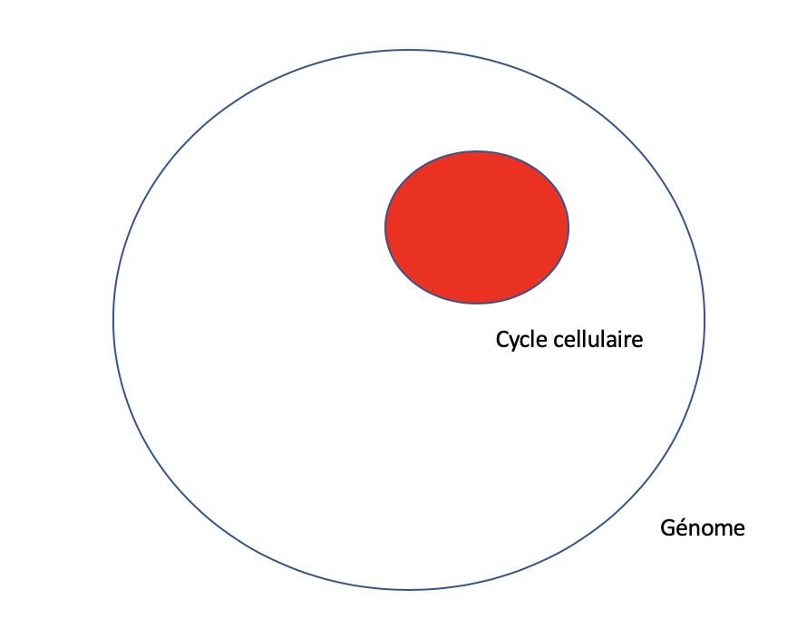

## Analyse fonctionnelle par enrichissement: principe (2)

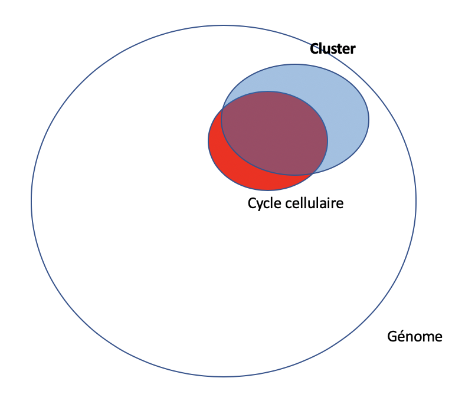

Comment quantifier l’enrichissement ?

## Analyse fonctionnelle par enrichissement: principe (3)

Exemple de calcul d’enrichissement: Je travaille avec

- 30000 gènes dont 2000 liés au **Cycle Cellulaire** (GO:0007049).
- J’ai identifié un **cluster** de 300 gènes.
- Ce cluster contient 100 gènes liés aux **Cycle cellulaire**.

Comment calculer l’enrichissement ?

\(E=\frac{100/300}{2000/30000} = 5\)

-> Il y a **Enrichissement** -> Validation statistique.

## Analyse fonctionnelle par enrichissement GO

Elles sont basées sur deux composantes:

- Elles utilisent une **Ontologie** (vocabulaire **contrôlé et stable** mis en place par le **Gene Ontology Consortium** ou autre (**Kyoto Encyclopedia of Genes and Genomes, KEGG**)).
- D’où l’utilisation fréquente du raccourcis (Enrichissement **GO**)
- Elles sont basées sur un **Enrichissement Fonctionnel** associé à une **validation statistique par Test Hypergéométrique**.

## Qu’est ce qu’une ontologie ?

Une ontologie est l’**ensemble structuré des termes et concepts représentant le sens d’un champ d’informations**, que ce soit par les métadonnées d’un espace de noms, ou les éléments d’un domaine de connaissances.

Application au génome: **Gene Ontology** (*Gene Ontology Consortium*http://www.amigo.org). 3 ontologies ont été définies.

- **Biological Process**
- **Cellular Component**
- **Molecular Function**

## Graphe GO

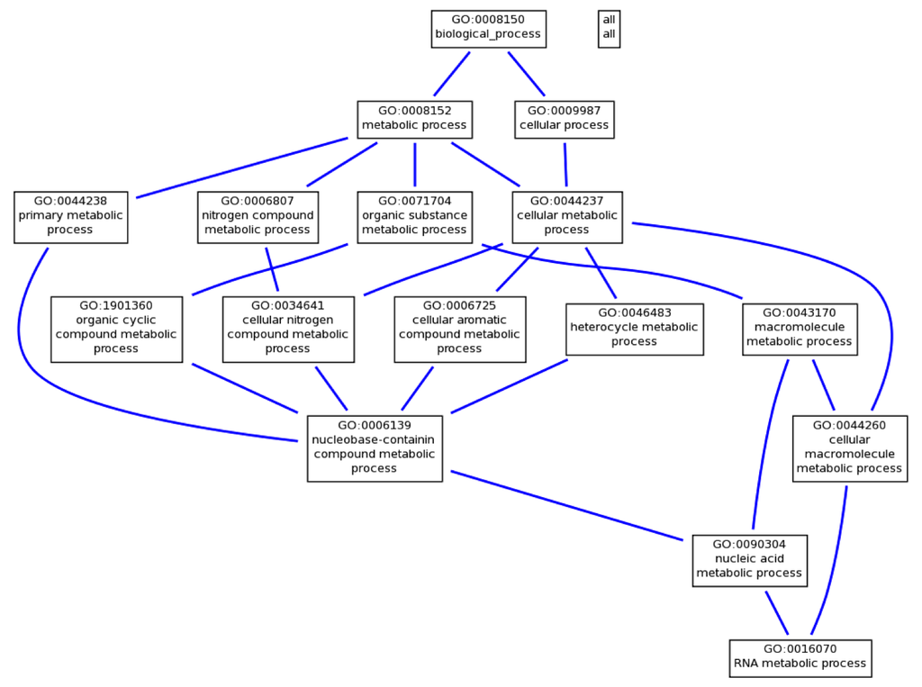

## Exemple d’annotation

Gène **RPL35A**

- GO:0000049 - tRNA binding
- GO:0000184 - nuclear-transcribed mRNA catabolic process, nonsense-mediated decay
- GO:0003735 - structural constituent of ribosome
- GO:0005829 – cytosol
- GO:0006364 - rRNA processing
- …

Annotations par un **vocabulaire contrôlé**.

## Test d’enrichissement GO

Une catégorie de gènes regroupe *n* gènes sur le total de *N* présents sur la puce. La fréquence de départ de cette catégorie est *F = n/N*.

L’enrichissement est défini comme *f/F*.

Le test d’enrichissement doit répondre à la question: L’enrichissement est-il **statistiquement significatif** par rapport à un tirage au hasard? On le fait par **Test hypergéométrique**.

## Exemple de résultat

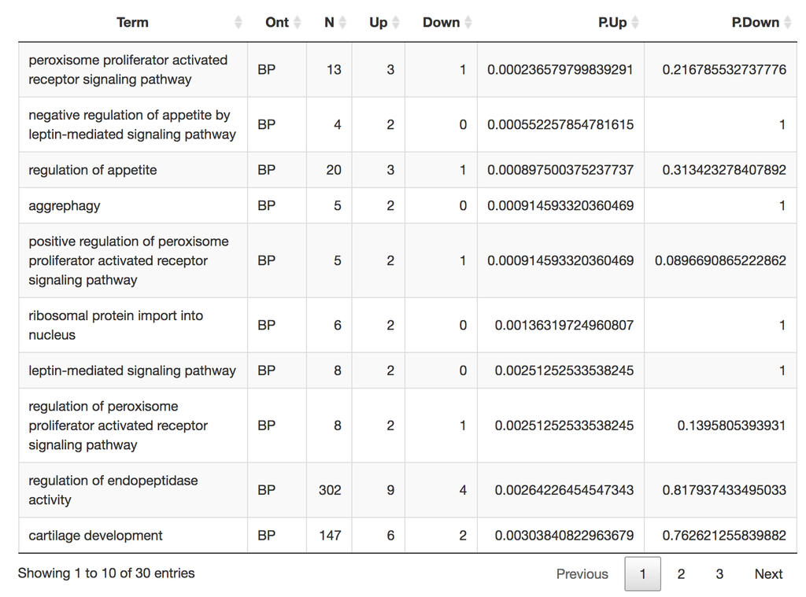

## Banques de données publiques NCBI

Il s’agit de dépôts de données liées à des publications répondant à des standards minimum de conservation et de reproducibilité de l’information, et contenant des données brutes de puces à ADN et de NGS.

L’information stockée permet la reproductibilité de l’expérience Leur usage est exigé pour publication (Numéro d’accession).

- **NCBI Gene Expression Omnibus** http://www.ncbi.nlm.nih.gov/geo/
- **EBI ArrayExpress** http://www.ebi.ac.uk/arrayexpress/

Dépôts spécialisés:

- The Cancer Cell Line Encyclopedia (CCLE) http://www.broadinstitute.org/ccle
- The Cancer Genome Atlas (TCGA) http://cancergenome.nih.gov/
- Immunological Genome Project (ImmGen) https://www.immgen.org/

## Bases d’annotations utiles

- Téléchargement de génomes de références (souris, humain et autres): UCSC http://hgdownload.cse.ucsc.edu/goldenPath/hg19/bigZips/hg19.2bit
- Téléchargement d’annotations sous format GFF (pour IGV): GENCODE https://www.gencodegenes.org/human/

## Autres services NCBI

PubMed:

http://www.ncbi.nlm.nih.gov/pubmed

- Recherches par *auteur*, *années*, *titre*, *contenu du résumé*
- Recherche par *publications en lien*
- Possibilité d’ouvrir un compte utilisateur NCBI (*Recherches favorites*, *Recherches automatisées*)
- Un grand nombre de publications sont accessibles de façon gratuite (*PubMed Central*)

## Petit Quizz

- En analyse NGS, la bioinformatique et l’infrastructure bioinformatique ne sont que peu ou pas importantes face au séquençage lui-même: (*Vrai/Faux*)
- Remettre dans l’ordre les phases d’analyses NGS suivantes:
  - Alignement
  - Détection des mutations et Production des VCFs
  - Visualisation
  - Réalignement pour recherche d’INDELS
  - Contrôle Qualité
- Faire correspondre les logiciels suivants à ces différentes étapes:
  - BWA
  - GATK
  - IGV
  - Varscan
  - FastQC

## Merci de votre attention !

Ghislain Bidaut

Responsable de la **plateforme Cibi** au **Centre de Recherche en Cancérologie de Marseille**

- Contact ghislain.bidaut@inserm.fr
- Site web http://cibi.marseille.inserm.fr

[figure not shown]

## Copyright

Ce(tte) œuvre est mise à disposition selon les termes de la [Licence Creative Commons Attribution - Pas d'Utilisation Commerciale - Pas de Modification 4.0 International](http://creativecommons.org/licenses/by-nc-nd/4.0/).

Copyright © Ghislain BIDAUT 2024